# MATH 140 R Activity - Exploring Data with R

March 5, 2026

# Introduction

The **tidyverse** package contains useful packages for managing and visualizing data. Today we use some commands from two packages in the tidyverse:

- dplyr (data verbs for managing data)
- ggplot (for creating wonderful plots)

## `dplyr`

*Data verbs* are commands designed to help us intuitively tackle data frame manipulation tasks. We discuss the syntax for doing data management with dplyr and the pipe command (`|>` or `%>%`) in class. A more detailed tutorial can be found on our [Data Management with dplyr](https://mphitchman.com/stats/datamanip.html) tutorial on our course resource page.

Here are some commonly used data verbs:

| dplyr command | Description |
| --- | --- |
| `filter()` | filter (subset) rows by a condition |
| `arrange()` | sort the data |
| `select()` | selecting columns (variables) |
| `mutate()` | create new variables (columns) |
| `slice()` | consider only the rows indicated |
| `group_by()` | group the data |
| `summarize()` | summarize or aggregate the data |

**Example**: Let’s say I have a data set called `lego` that has many columns, three of which are called `name` (the name of the set), `pieces` (how many pieces it has), and `cost`. Then the code

```r
lego |>
  filter(pieces > 500) |>
  arrange(desc(cost)) |>
  select(name,pieces,cost)
```

would be interpreted to mean this: take the data set `lego`, then filter the data set to include just those sets that have more than 500 pieces. Then sort those rows in descending order by how much they cost. Then select just the three columns `name`, `pieces`, and `cost` to disply.

The pipe command `|>` essentially means **then**

## `ggplot`

We discuss the anatomy of a ggplot in class. A more detailed tutorial can be found on our [Data Visualization with ggplot](https://mphitchman.com/stats/dataviz.html) tutorial on our course resource page.

We can choose to make a histogram,

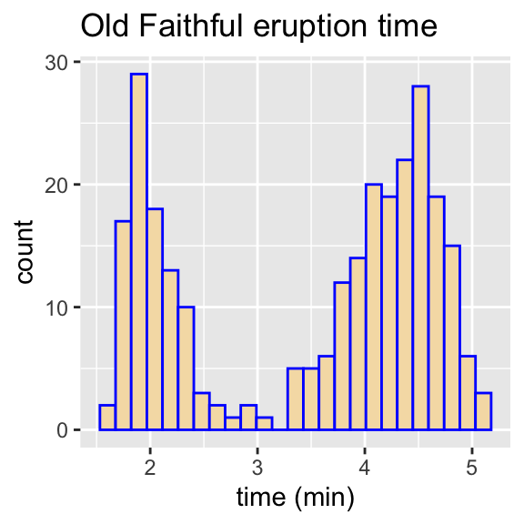

```r
ggplot(faithful)+
  geom_histogram(aes(x = eruptions), fill = 'wheat', col = 'blue',bins = 25)+
  labs(title = 'Old Faithful eruption time',
       x = 'time (min)')
```

or a boxplot,

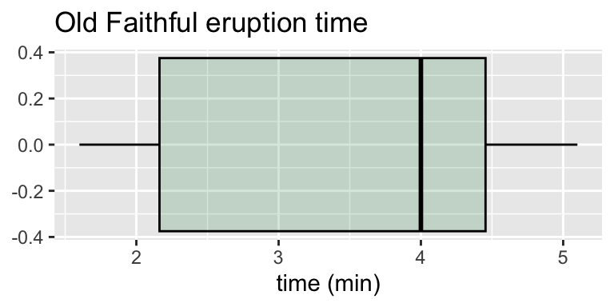

```r
ggplot(faithful)+
  geom_boxplot(aes(x = eruptions), fill = 'seagreen', col = 'black', alpha = .2)+
  labs(title = 'Old Faithful eruption time',
       x = 'time (min)')
```

or a bar plot (to summarize the frequency distribution of a categorical variable)

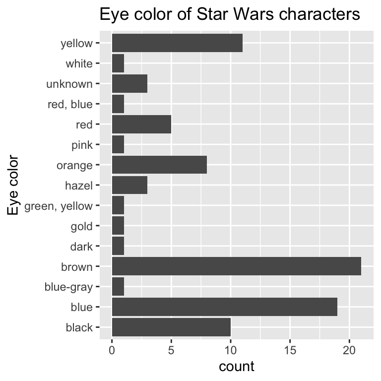

```r
ggplot(starwars)+
  geom_bar(aes(y = eye_color))+
  labs(title = 'Eye color of Star Wars characters',
       y = 'Eye color')
```

# Q0. Setup

We will work through these steps together in class.

> 1. Fire up RStudio
> 2. Create a new script.
> 3. Enter your Name as a comment in line 1 of your script, e.g.,

`# Mike Hitchman`

> 4. Load the tidyverse into your session by typing `library(tidyverse)` in line 2 of your script and then running the line.
> 5. We will talk as a class about the expected format of your script as you proceed. Your script will record code you use to accompish tasks, as well as comments (beginning with #) when you are asked to discuss the code outputs.
> 6. When you are done with this activity you will submit your script to blackboard - we will go over how to do this.

# Q1. The data

> 1. Load the rectangles data into your session by copying the line below into your script, and then running the line. To see if it loaded, check that `df` appears in your environment tab.

```r
df <- read.csv("https://mphitchman.com/stats/data/mph_rectangles.csv")
```

> 2. Run `summary(df)` (enter this into your script) to obtain a quick summary of what the data frame contains. Then answer these questions as comments in your script.
- How many observations are there?
- Name each variable, and indicate whether it is categorical or numerical.
> 3. What are the different rectangle colors in this data set, and how many of each color are there? Use code to answer this question, and summarize your answer with a comment.

**Intermission**: Here’s what my script looks like after I have completed Q1.

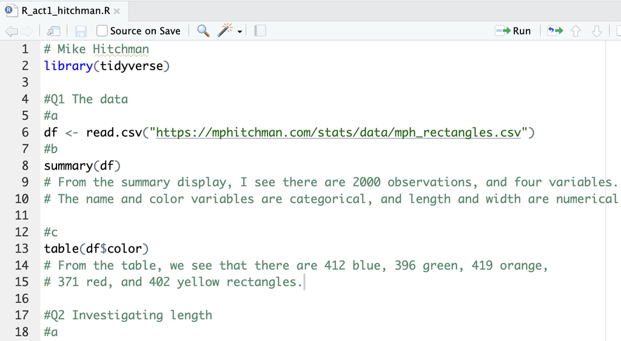

**End Intermission**

# Q2. Investigating `length`

> 1. Use `mean()` and `sd()` to find the the mean and standard deviation of the `length` variable.
> 2. Determine the IQR of the `length` variable.
> 3. Visualize the distribution of lengths with a ggplot histogram. Comment in your script about the shape of the distribution (e.g., symmetric and bell-shaped, uniform, skewed right, skewed left, outliers…). Feel free to adjust plot colors and change how many bins to use. Find a plot that gives you a good sense of the overall shape of the distribution.

# Q3. Investigating `width`

> Repeat Q2 with the `width` variable.

# Q4. Comparing IQRs

> Which variable, `length` or `width`, has a larger IQR? Comment on why this answer is reasonable given the shapes of the two distributions.

# Q5. Association (num vs num)

> What kind of association is there, if any, between a rectangle’s width and its length? Make a **point plot** to inform your response.

Using `ggplot()`, use plot “geometry” is `geom_point()` for a point plot (aka ‘scatter plot’).

# Q6. Association (cat vs num)

> What kind of association is there, if any, between a rectangle’s `color` and its `width`? Make side-by-side boxplots (by color groups) to inform your response. With `ggplot`, use `geom_boxplot` for a boxplot, and the aesthetic in this case would be `aes(x = width, y = color)` if you want horizontal boxplots of width grouped by color.

**Intermission**: Counting how many observations meet some criteria.

We can use the `sum()` command to see how many elements in a vector meet some condition.

For instance, how many elements in the vector `x` below have a value greater than 10?

```r
x = c(3, 13, 7, 12, 10, 4, 5)
sum(x > 10)
```

```
## [1] 2
```

Or, how many elements in `x` are between 6 and 11?

```r
sum(x > 6 & x < 11)
```

```
## [1] 2
```

Or, how many rectangles in the data frame have width $w$ such that $12 \leq w \leq 12.5$?

```r
sum(df$width >= 12 & df$width <= 12.5)
```

```
## [1] 325
```

So, the *proportion* of all rectangles with a width in this range is

```r
sum(df$width >= 12 & df$width <= 12.5) / nrow(df)
```

```
## [1] 0.1625
```

In other words, if I pick a rectangle at random from this data set, the probability is 0.1625 that its width is between 12 and 12.5.

**End Intermission**

# Q7. Conditional Counts

> What proportion of retangles have length between 14 and 15?

**Intermission**: Sorting and filtering data.

We use the `filter()` verb to find those rows (observations) that meet some condition (or conditions) for a variable. We use the `arrange()` verb to sort by a column.

**Example 1**: List all the rectangles named `Mike`?

```r
df |>
  filter(name == 'Mike')
```

```
##   name length width color
## 1 Mike  13.54 13.48 green
```

**Example 2**: What are the five widest yellow rectangles? List them in descending order.

Strategy:

- First take the data, then
- `filter()` the data to include just the yellow rectangles, then
- `arrange()` these data in `desc()` order by their `width`, then
- `slice()` off just rows 1 through 5 for display.

```r
df |>
  filter(color == 'yellow') |>
  arrange(desc(width)) |>
  slice(1:5)
```

```
##      name length width  color
## 1  Butler  13.09 14.49 yellow
## 2  Peggie  12.97 14.48 yellow
## 3 Kennard  12.36 14.48 yellow
## 4    Euna  13.06 14.47 yellow
## 5  Deidre  13.01 14.47 yellow
```

**Example 3**: List in alphabetical order all red rectangles that are at least 2 units longer than they are wide.

Strategy:

- First take the data, then
- `filter()` the data to include just the red rectangles that also have (length - width) at least 2, then
- `arrange()` these data by their `name` (by default `arrange`() sorts a column in ascending order).

```r
df |>
  filter(color == 'red' & (length - width) >= 2) |>
  arrange(name)
```

```
##      name length width color
## 1  Berton  14.24 11.80   red
## 2 Cornell  13.81 11.60   red
## 3   Netta  13.69 11.57   red
## 4  Nyasia  13.69 11.51   red
```

**End Intermission**

# Q8. Filter and Sort

> 1. Among all the green rectangles with length greater than 13, find the name of the one with the smallest width.
> 2. Among all rectangles with width less than 12, find the name and color of the one with the greatest length.